# Confetti Quadrat Sampling Analysis

Junru Zhao

2026-02-26

#Introduction

This notebook demonstrates how quadrat sampling is used to estimate the total abundance of objects in a large area, and how statistical uncertainty (standard error) arises from sampling variability.

This example simulates ecological field sampling, such as estimating sea urchin or kelp density using quadrats.

#Step 1: Raw data from quadrat sampling

Each value represents the number of confetti found in a single 10*10 cm quadrat.

```r
x <- c(4, 2, 5, 2, 5, 4, 11, 5, 9, 7,
       2, 1, 7, 1, 17, 3, 17, 3, 0, 9,
       4, 12, 2, 8, 0, 10, 2, 4, 0, 3)

n <- length(x)
n
```

```
## [1] 30
```

Interpretation:

We sampled 30 quadrats from a large area.

#Step 2: Visualize distribution

Histogram shows frequency distribution.

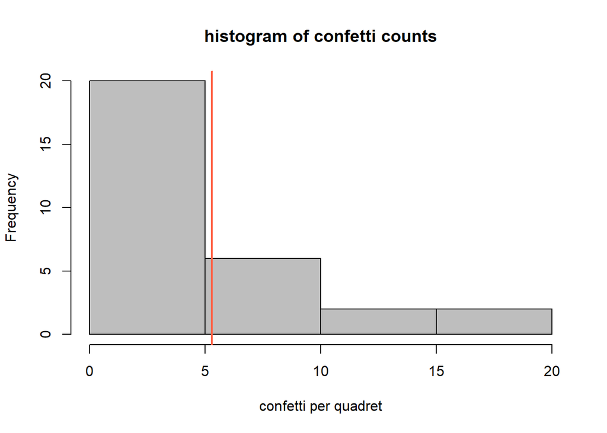

```r
hist(x,xlab = "confetti per quadret", main="histogram of confetti counts", col= "gray" )
abline(v= mean(x), col="tomato", lwd=2)
```

red line is sample mean.

#step 3: probability density modle kernel density estimation creates a smooth probability model

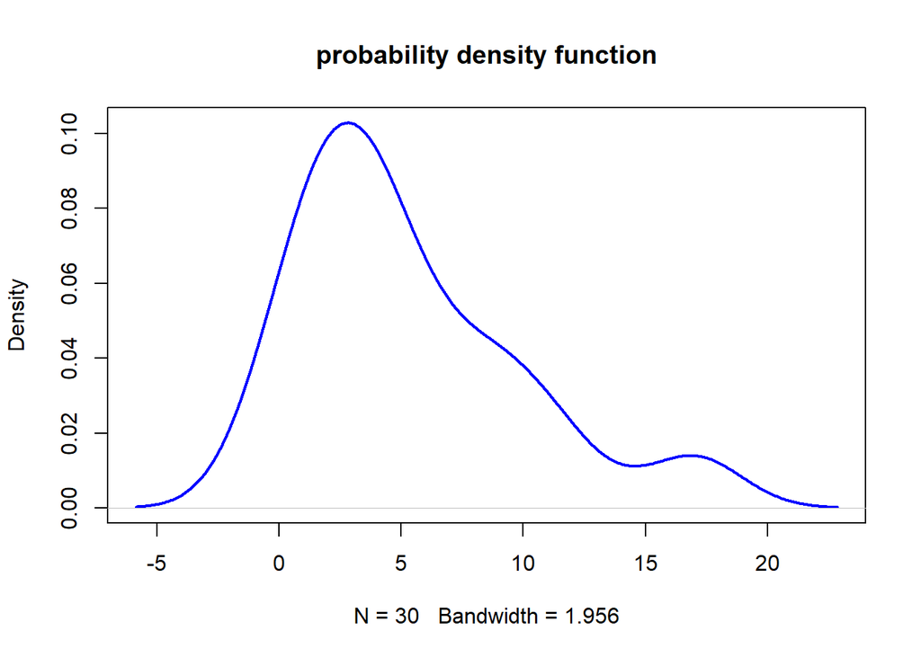

```r
d<- density(x)
plot(d, main = "probability density function",
     lwd=2,
     col= "blue")
```

which gives the probability of confetti counts / quadrats

#step 4: sample statistics

```r
mean_x <-mean(x)
sd_x<- sd(x)
variance_x <- var(x)

mean_x
```

```
## [1] 5.3
```

```r
sd_x
```

```
## [1] 4.594975
```

```r
variance_x
```

```
## [1] 21.11379
```

mean_x -> estimated confetti/quadrats sd_z -> spatial variability between each quadrats variance_x -> squared variability

#step 5: estimate total confetti in all area total area contains 800 quadrats

```r
total_quadrats <- 800
total_estimate <- mean_x * total_quadrats
total_estimate
```

```
## [1] 4240
```

it is more like to time a ratio

#Step 6: Standard error of the mean Standard error represents uncertainty in the mean estimate.

SE does not describe how much the raw data vary — it describes how much the estimated mean itself would vary if the sampling experiment were repeated. If multiple independent teams repeat the same sampling procedure, each team will obtain its own estimate of the total confetti. In this case, the standard error can be directly calculated as the standard deviation of these repeated estimates:

```r
# Example: total estimates from multiple independent teams
mean_x <- c(4240, 4160, 5040, 5352, 6213, 6219)
# Empirical standard error (true definition)
se_total_empirical <- sd(mean_x)
se_total_empirical
```

```
## [1] 907.341
```

This value represents how much the estimated total confetti varies across repeated independent sampling experiments. This is the true frequentist definition of standard error. However, in most real-world situations, we only perform the sampling once. We do not have multiple repeated experiments. In this case, statisticians use a mathematical approximation to estimate the standard error of the mean:

```r
standard_error <- sd_x / sqrt(n)
standard_error
```

```
## [1] 0.8389238
```

#Step 7: Standard error of total estimate Since our final goal is to estimate the total confetti in the entire rectangle, we scale this uncertainty proportionally to the total number of quadrats:

```r
total_standard_error <- total_quadrats * standard_error
total_standard_error
```

```
## [1] 671.139
```

#Step 8: Final estimate with uncertainty

```r
lower <- total_estimate - total_standard_error
upper <- total_estimate + total_standard_error

total_estimate
```

```
## [1] 4240
```

```r
lower
```

```
## [1] 3568.861
```

```r
upper
```

```
## [1] 4911.139
```

```r
cat("Estimated total confetti:",
    total_estimate,
    "+/-",
    total_standard_error)
```

```
## Estimated total confetti: 4240 +/- 671.139
```

#Summary: With repeated independent sampling: Standard error = standard deviation of repeated estimates (empirical definition)

With only a single sampling event: Standard error ≈ sd(sample) / sqrt(n) (theoretical approximation)

This approximation allows us to estimate uncertainty even when repeated experiments are not available.